# Analyzing Individual BGG Users

Phil Henrickson

2022-01-02

# **CptToast’s** BoardGameGeek Collection

This notebook contains a set of analyses for the selected user’s boardgamegeek collection. The bulk of the analysis is focused on building a user-specific predictive model to predict the games that CptToast is likely to own. This enables to ask questions like, based on the games the user currently owns, what games are a good fit for their collection? What upcoming games are they likely to purchase?

This analysis is based on data from BoardGameGeek that was last updated on **2021-12-20.**

# 1 Collection Overview

We can look at a basic description of the number of games that the user owns, has rated, has previously owned, etc.

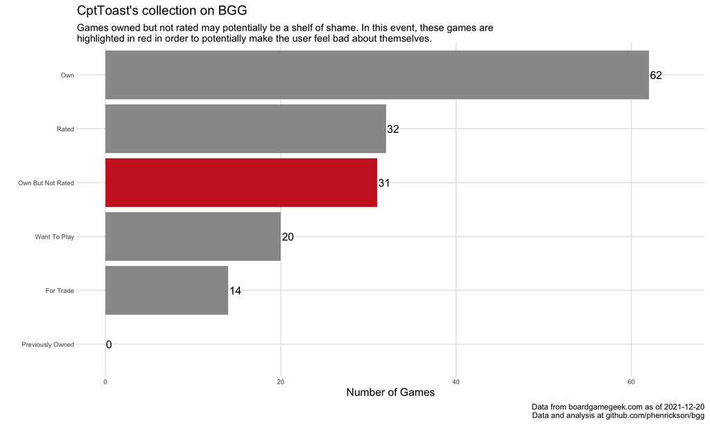

What years has the user owned/rated games from? While we can’t see when a user added or removed a game from their collection, we can look at their collection by the years in which their games were published.

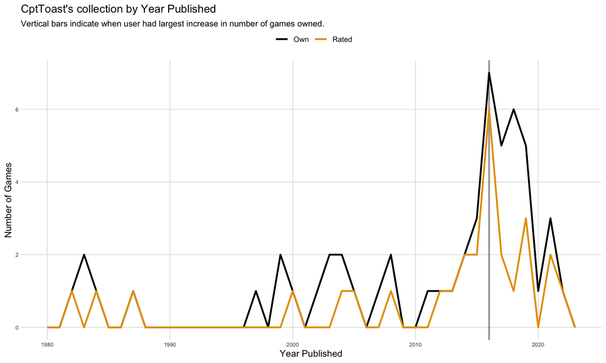

## 1.1 What types of games does CptToast own?

We can look at the most frequent types of categories, mechanics, designers, and artists that appear in a user’s collection.

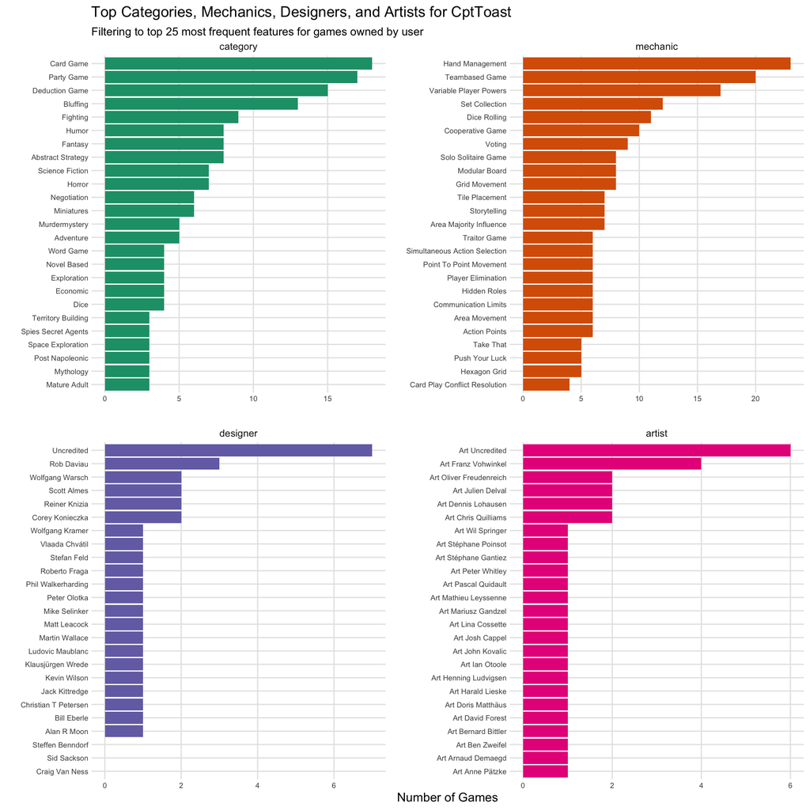

# 2 Modeling **CptToast’s** Collection

| username | dataset | period | games_owned | games_rated | games_played |
| --- | --- | --- | --- | --- | --- |
| CptToast | training | published before 2020 | 56 | 29 | 57 |
| CptToast | test | published 2020 or later | 5 | 3 | 5 |

There are two main (binary) outcomes we will be modeling for the user.

The first, **own** refers to whether the user currently lists a game as owned in their collection. The second, **played** refers to whether the user currently owns, has rated, or previously owned a game. This means the latter will generally have a larger list of games, but may still be a useful category to examine for people who play lots of games without necessarily owning them.

We will train predictive models to learn the probability that the user will own or play individual games based on their features.

## 2.1 Coefficients for CptToast

We can examine coefficients from the trained modes, which are penalized logistic regressions fit to our two main outcomes. Positive values indicate that a feature increases a user’s probabilility of owning/rating a game, while negative values indicate a feature decreases the probability.

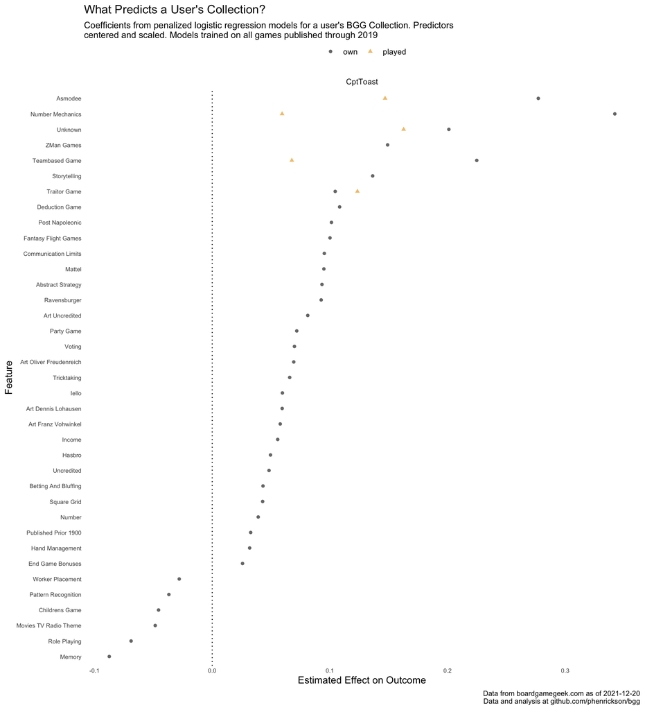

## 2.2 Visualizing Predictors for CptToast’s Collection

Why did the model identify these features? We can make density plots of the important features for predicting whether the user owned a game. Blue indicates the density for games owned by the user, while grey indicates the density for games not owned by the user.

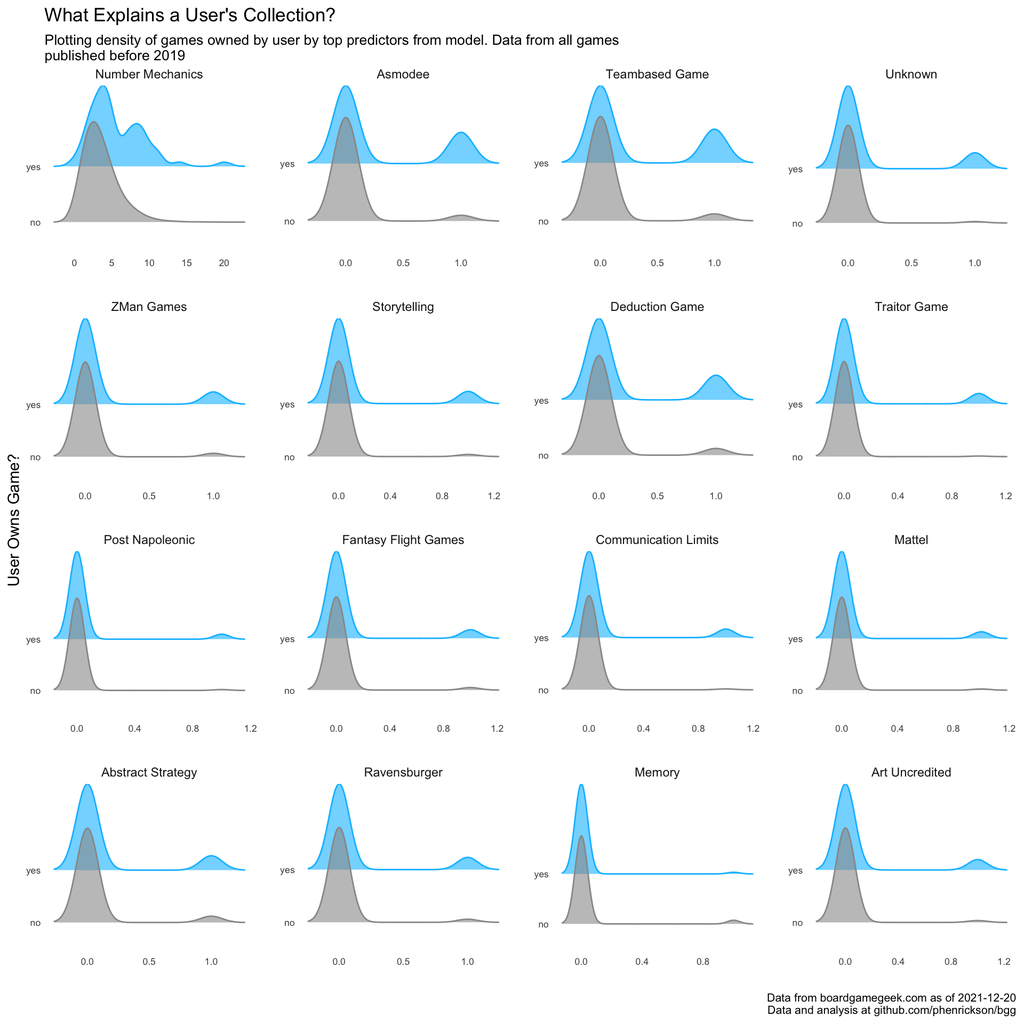

Binary predictors can be difficult to see with this visualization, so we can also directly examine the percentage of games in a user’s collection with a predictor vs the percentage of all games with that predictor.

| username | Feature | % of Games with Feature In_Collection | % of Games with Feature All_Games | Ratio |
| --- | --- | --- | --- | --- |
| CptToast | Traitor Game | 10.7% | 0.6% | 17.6 |
| CptToast | Unknown | 16.1% | 1.4% | 11.5 |
| CptToast | Communication Limits | 8.9% | 0.9% | 9.4 |
| CptToast | Income | 5.4% | 0.7% | 7.6 |
| CptToast | Post Napoleonic | 5.4% | 0.9% | 6.1 |
| CptToast | Storytelling | 12.5% | 2.2% | 5.8 |
| CptToast | Mattel | 7.1% | 1.2% | 5.7 |
| CptToast | Asmodee | 28.6% | 5.2% | 5.4 |
| CptToast | Voting | 12.5% | 2.4% | 5.3 |
| CptToast | Square Grid | 7.1% | 1.4% | 5.1 |
| CptToast | Teambased Game | 30.4% | 6.2% | 4.9 |
| CptToast | Ravensburger | 12.5% | 3.1% | 4.0 |
| CptToast | Deduction Game | 23.2% | 6.3% | 3.7 |
| CptToast | ZMan Games | 12.5% | 3.5% | 3.6 |
| CptToast | Betting And Bluffing | 7.1% | 2.0% | 3.5 |
| CptToast | Fantasy Flight Games | 8.9% | 2.6% | 3.4 |
| CptToast | Tricktaking | 5.4% | 1.7% | 3.2 |
| CptToast | Hasbro | 12.5% | 3.9% | 3.2 |
| CptToast | Party Game | 25.0% | 8.4% | 3.0 |
| CptToast | Iello | 8.9% | 3.1% | 2.9 |
| CptToast | Abstract Strategy | 14.3% | 6.3% | 2.3 |
| CptToast | Role Playing | 3.6% | 3.2% | 1.1 |
| CptToast | Movies TV Radio Theme | 1.8% | 4.0% | 0.5 |
| CptToast | Memory | 1.8% | 4.0% | 0.4 |
| CptToast | Childrens Game | 0.0% | 5.7% | 0.0 |

# 3 Assess Model’s Performance on Training Set

Before predicting games in upcoming years, we can examine how well the model did and what games it liked in the training set. In this case, we used resampling techniques (cross validation) to ensure that the model had not seen a game before making its predictions.

## 3.1 Separation Plot

An easy way to examine the performance of classification model is to view a separation plot. We plot the predicted probabilities from the model for every game (from resampling) from lowest to highest. We then overlay a blue line for any game that the user does own. A good classifier is one that is able to *separate* the blue (games owned by the user) from the white (games not owned by the user), with most of the blue occurring at the highest probabilities (right side of the chart).

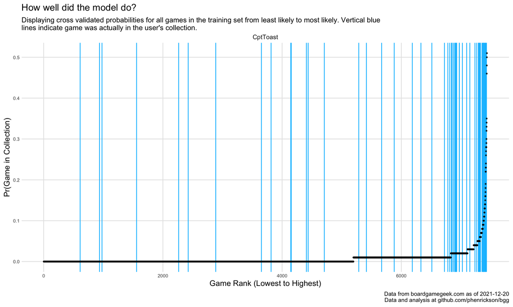

## 3.2 Top Games for **CptToast** from Training Set

We can display this information in table form, displaying the 100 games with the highest probability of ownership, adding a blue line when the user does own the game.

| username | yearpublished | game_id | name | pred_played | pred_own | actual_played | actual_own |
| --- | --- | --- | --- | --- | --- | --- | --- |
| CptToast | 1900 | 45 | Perudo | 0.12 | 0.51 | 0 | 0 |
| CptToast | 1900 | 7316 | Bingo | 0.02 | 0.50 | 0 | 0 |
| CptToast | 2008 | 37111 | Battlestar Galactica: The Board Game | 0.07 | 0.48 | 0 | 0 |
| CptToast | 2004 | 9220 | Saboteur | 0.10 | 0.46 | 0 | 0 |
| CptToast | 2016 | 205716 | New Angeles | 0.09 | 0.35 | 0 | 0 |
| CptToast | 2014 | 150376 | Dead of Winter: A Crossroads Game | 0.03 | 0.34 | 0 | 0 |
| CptToast | 2013 | 127024 | Room 25 | 0.04 | 0.33 | 0 | 0 |
| CptToast | 2017 | 174430 | Gloomhaven | 0.01 | 0.32 | 1 | 1 |
| CptToast | 2014 | 152241 | Ultimate Werewolf | 0.05 | 0.30 | 0 | 0 |
| CptToast | 2018 | 205896 | Rising Sun | 0.03 | 0.29 | 0 | 0 |
| CptToast | 1900 | 2389 | Othello | 0.05 | 0.28 | 0 | 0 |
| CptToast | 2000 | 478 | Citadels | 0.02 | 0.28 | 0 | 0 |
| CptToast | 2005 | 15062 | Shadows over Camelot | 0.06 | 0.28 | 0 | 0 |
| CptToast | 1900 | 2386 | Chinese Checkers | 0.08 | 0.28 | 0 | 0 |
| CptToast | 1900 | 2394 | Dominoes | 0.02 | 0.28 | 0 | 0 |
| CptToast | 1900 | 2136 | Pachisi | 0.06 | 0.27 | 0 | 0 |
| CptToast | 2015 | 181304 | Mysterium | 0.01 | 0.26 | 0 | 0 |
| CptToast | 2011 | 59959 | Letters from Whitechapel | 0.03 | 0.24 | 0 | 0 |
| CptToast | 2009 | 56885 | The Werewolves of Miller's Hollow: The Village | 0.13 | 0.23 | 0 | 0 |
| CptToast | 2014 | 156129 | Deception: Murder in Hong Kong | 0.02 | 0.23 | 1 | 1 |
| CptToast | 2016 | 198454 | When I Dream | 0.02 | 0.22 | 0 | 0 |
| CptToast | 2016 | 205059 | Mansions of Madness: Second Edition | 0.07 | 0.22 | 0 | 0 |
| CptToast | 1933 | 1406 | Monopoly | 0.05 | 0.19 | 0 | 0 |
| CptToast | 1986 | 925 | Werewolf | 0.06 | 0.18 | 0 | 0 |
| CptToast | 1997 | 2633 | DOG | 0.03 | 0.17 | 0 | 0 |
| CptToast | 2016 | 205398 | Citadels | 0.04 | 0.16 | 0 | 0 |
| CptToast | 2004 | 10547 | Betrayal at House on the Hill | 0.08 | 0.16 | 1 | 1 |
| CptToast | 2019 | 245655 | The King's Dilemma | 0.05 | 0.16 | 0 | 0 |
| CptToast | 2019 | 273477 | Obscurio | 0.02 | 0.15 | 0 | 0 |
| CptToast | 2017 | 224037 | Codenames: Duet | 0.01 | 0.14 | 0 | 0 |

[output cut: 70 more lines]

We can also more formally assess how well the model did in resampling by looking at the area under the receiver operating characteristic. A perfect model would receive a score of 1, while a model that cannot predict the outcome will default to a score of 0.5. The extent to which something is a *good* score depends on the setting, but generally anything in the .8 to .9 range is very good while the .7 to .8 range is perfectly acceptable.

| username | outcome_type | .metric | .estimator | .estimate |
| --- | --- | --- | --- | --- |
| CptToast | own | roc_auc | binary | 0.816 |
| CptToast | played | roc_auc | binary | 0.793 |

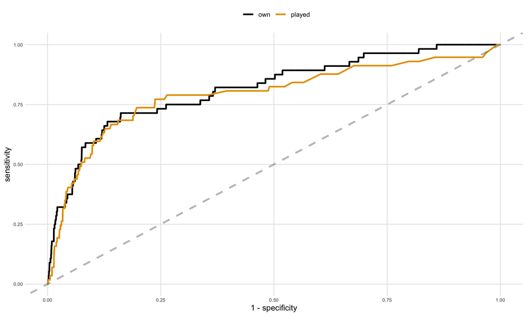

Another way to think about the model performance is to view its lift, or its ability to detect the positive outcomes over that of a null model. High lift indicates the model can much more quickly find all of the positive outcomes (in this case, games owned or played by the user), while a model with no lift is no better than random guessing.

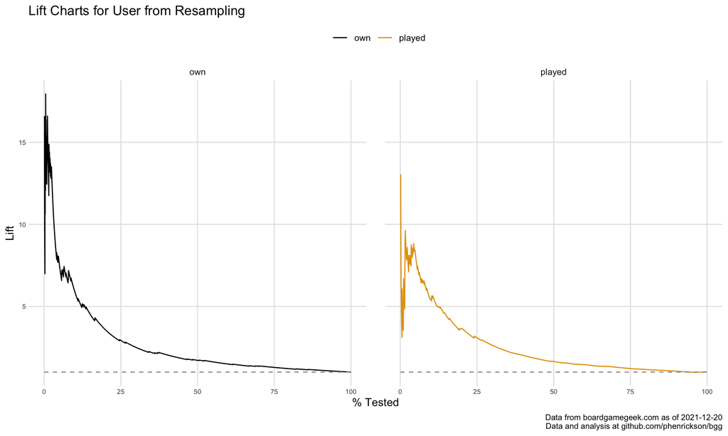

## 3.3 Most and Least Likely Games

What games does the model think CptToast is **most likely to own** that are **not** in their collection?

| username | yearpublished | game_id | name | pred_own | actual_own |
| --- | --- | --- | --- | --- | --- |
| CptToast | 1900 | 45 | Perudo | 0.51 | 0 |
| CptToast | 1900 | 7316 | Bingo | 0.50 | 0 |
| CptToast | 2008 | 37111 | Battlestar Galactica: The Board Game | 0.48 | 0 |
| CptToast | 2004 | 9220 | Saboteur | 0.46 | 0 |
| CptToast | 2016 | 205716 | New Angeles | 0.35 | 0 |

What games does the model think CptToast is **least likely to own** that **are** in their collection?

| username | yearpublished | game_id | name | pred_own | actual_own |
| --- | --- | --- | --- | --- | --- |
| CptToast | 1975 | 2409 | Duell | 0 | 1 |
| CptToast | 2003 | 6368 | King Arthur | 0 | 1 |
| CptToast | 2011 | 84876 | The Castles of Burgundy | 0 | 1 |
| CptToast | 2019 | 257283 | Tiny Epic Mechs | 0 | 1 |
| CptToast | 1999 | 348 | Merchants of the Middle Ages | 0 | 1 |

## 3.4 Top Games by Year

Top 25 games most likely to be owned by the user in each year, highlighting in blue the games that the user has owned/played.

| rank | 2011 | 2012 | 2013 | 2014 | 2015 | 2016 | 2017 | 2018 | 2019 |
| --- | --- | --- | --- | --- | --- | --- | --- | --- | --- |
| 1 | Letters from Whitechapel | The Resistance: Avalon | Room 25 | Dead of Winter: A Crossroads Game | Mysterium | New Angeles | Gloomhaven | Rising Sun | The King's Dilemma |
| 2 | Takenoko | One Night Werewolf | Concept | Ultimate Werewolf | The Voyages of Marco Polo | When I Dream | Codenames: Duet | Human Punishment: Social Deduction 2.0 | Obscurio |
| 3 | Tragedy Looper | Archipelago | A Study in Emerald | Deception: Murder in Hong Kong | Unusual Suspects | Mansions of Madness: Second Edition | Gaia Project | Decrypto | Maracaibo |
| 4 | Panic Station | Coup | Tash-Kalar: Arena of Legends | Spyfall | Salem 1692 | Citadels | Fallout | Shadows: Amsterdam | Era: Medieval Age |
| 5 | Dungeon Fighter | Robinson Crusoe: Adventures on the Cursed Island | BANG! The Dice Game | Witness | Codenames | Sherlock Holmes Consulting Detective: Jack the Ripper & West End Adventures | Sherlock Holmes Consulting Detective: Carlton House & Queen's Park | Newton | One Key |
| 6 | Flash Point: Fire Rescue | Winter Tales | Ultimate Werewolf: Inquisition | Ultimate Werewolf: Deluxe Edition | Mafia de Cuba | Codenames: Deep Undercover | Werewords | Detective Club | Clank!: Legacy – Acquisitions Incorporated |
| 7 | Principato | Serenissima (Second Edition) | Glass Road | One Night Ultimate Werewolf | One Night Ultimate Werewolf: Daybreak | Dead of Winter: The Long Night | The Thing: Infection at Outpost 31 | Muse: Awakenings | The Magnificent |
| 8 | Dixit: Odyssey | The Last Banquet | Corto | Akrotiri | The Game | Secret Hitler | Pandemic Legacy: Season 2 | First Contact | Last Bastion |
| 9 | A Few Acres of Snow | Dixit: Journey | LEADERS: The Combined Strategy Game | Don't Mess with Cthulhu | T.I.M.E Stories | Game of Thrones: The Iron Throne | Secrets | Werewords Deluxe Edition | Tapestry |
| 10 | Space Empires: 4X | Lift it! | Ladies & Gentlemen | Sheriff of Nottingham | The Bloody Inn | A Feast for Odin | Betrayal at Baldur's Gate | The World of SMOG: Rise of Moloch | KeyForge: Age of Ascension |
| 11 | Alcatraz: The Scapegoat | Zombicide | Bruxelles 1893 | Patchwork | Grimslingers | Beyond Baker Street | This War of Mine: The Board Game | Betrayal Legacy | Choose Your Own Adventure: War with the Evil Power Master |
| 12 | Mage Knight Board Game | Libertalia | Legacy: The Testament of Duke de Crecy | Castles of Mad King Ludwig | One Night Ultimate Vampire | Hit Z Road | Whitehall Mystery | Treasure Island | Batman: Gotham City Chronicles |
| 13 | Rory's Story Cubes: Voyages | Keyflower | Prosperity | Camel Up | March of the Ants | Pandemic: Reign of Cthulhu | Photosynthesis | Gen7: A Crossroads Game | Call to Adventure |
| 14 | Dark Moon | Space Cadets | The Phantom Society | Fields of Arle | Specter Ops | Codenames: Pictures | Codenames: Disney – Family Edition | Vengeance | Machina Arcana (Second/Third Edition) |
| 15 | Eclipse | Terra Mystica | Space Cadets: Dice Duel | Five Tribes | Exploding Kittens: NSFW Deck | Pandemic: Iberia | Twilight Imperium: Fourth Edition | One Week Ultimate Werewolf | Tainted Grail: The Fall of Avalon |
| 16 | The Walking Dead: The Board Game | Descent: Journeys in the Dark (Second Edition) | Blood Bound | Helios | Bastion | Burke's Gambit | Fog of Love | Nemesis | Marco Polo II: In the Service of the Khan |
| 17 | Mundus Novus | Targi | Rory's Story Cubes: Prehistoria | Bucket of Doom | Argonauts | The Others | Codenames: Marvel | Pandemic: Fall of Rome | Medium |
| 18 | Skull | Mice and Mystics | Two Rooms and a Boom | Deus | The King Is Dead | DOOM: The Board Game | The Chameleon | Narcos: The Board Game | Unlock!: Exotic Adventures – Expedition: Challenger |
| 19 | Rumble in the House | Divided Republic | Tomorrow | Splendor | Feelinks | Terraforming Mars | Muse | Lords of Hellas | Sabotage |
| 20 | Mansions of Madness | War of the Ring: Second Edition | Impulse | Alchemists | Zombicide Season 3: Rue Morgue | Final Touch | Unlock!: Escape Adventures – The Elite | The City of Kings | The Isle of Cats |
| 21 | Tales & Games: The Hare & the Tortoise | Kairo | Funemployed | Sentinel Tactics: The Flame of Freedom | Super Dungeon Explore: Forgotten King | Captain Sonar | Majesty: For the Realm | Trapwords | Middara: Unintentional Malum – Act 1 |
| 22 | Sekigahara: The Unification of Japan | Crazy Creatures of Dr. Gloom | Spyrium | Three Kingdoms Redux | Fury of Dracula (Third/Fourth Edition) | StoryLine: Fairy Tales | Cutthroat Kingdoms | Don't Mess with Cthulhu Deluxe | Sierra West |
| 23 | Ascension: Return of the Fallen | Sky Tango | Lewis & Clark: The Expedition | Chimera | Exploding Kittens | Tempel des Schreckens | One Night Ultimate Alien | Ultimate Werewolf Legacy | Jaws |
| 24 | Streams | Love Letter | BattleLore: Second Edition | Stay Away! | Sylvion | Black Orchestra | The Shipwreck Arcana | Western Legends | Day Night Z |
| 25 | Ventura | Wits & Wagers Party | Dungeon Twister: The Card Game | BANG!: The Walking Dead | Blood Rage | Scythe | Battlestations: Second Edition | Arkham Horror (Third Edition) | Unmatched: Battle of Legends, Volume One |

## 3.5 Interactive Predictions from Resampling

Interactive table for predictions from resampling.

|  | username | yearpublished | rank | game_id | name | pred_played | pred_own | actual_played | actual_own |
| --- | --- | --- | --- | --- | --- | --- | --- | --- | --- |
| 1 | CptToast | 1900 | 1 | 45 | Perudo | 0.12 | 0.51 | 0 | 0 |
| 2 | CptToast | 1900 | 2 | 7316 | Bingo | 0.02 | 0.5 | 0 | 0 |
| 3 | CptToast | 1900 | 11 | 2389 | Othello | 0.05 | 0.28 | 0 | 0 |
| 4 | CptToast | 1900 | 14 | 2386 | Chinese Checkers | 0.08 | 0.28 | 0 | 0 |
| 5 | CptToast | 1900 | 15 | 2394 | Dominoes | 0.02 | 0.28 | 0 | 0 |
| 6 | CptToast | 1900 | 16 | 2136 | Pachisi | 0.06 | 0.27 | 0 | 0 |
| 7 | CptToast | 1900 | 34 | 10799 | Old Maid | 0.02 | 0.14 | 0 | 0 |
| 8 | CptToast | 1900 | 35 | 171 | Chess | 0.02 | 0.13 | 1 | 1 |
| 9 | CptToast | 1900 | 43 | 15549 | Roulette | 0.05 | 0.12 | 0 | 0 |
| 10 | CptToast | 1900 | 45 | 2083 | Checkers | 0.01 | 0.11 | 0 | 0 |

[output cut: 7426 more lines]

# 4 Validating the Model on 2020

How well did a model trained on a user’s collection through 2019 perform in predicting games for the user from 2020?

| username | outcome_type | yearpublished | .metric | .estimator | .estimate |
| --- | --- | --- | --- | --- | --- |
| CptToast | own | 2020 | roc_auc | binary | 0.973 |
| CptToast | played | 2020 | roc_auc | binary | 0.949 |

Table of top 25 games from 2020, highlighting games that the user owns.

| username | yearpublished | game_id | name | pred_own | pred_played | actual_own | actual_played |
| --- | --- | --- | --- | --- | --- | --- | --- |
| CptToast | 2020 | 291457 | Gloomhaven: Jaws of the Lion | 0.17 | 0.02 | 0 | 0 |
| CptToast | 2020 | 296892 | Sacred Rites | 0.11 | 0.03 | 0 | 0 |
| CptToast | 2020 | 301767 | Mysterium Park | 0.11 | 0.01 | 0 | 0 |
| CptToast | 2020 | 307997 | Insider Black | 0.09 | 0.04 | 0 | 0 |
| CptToast | 2020 | 256317 | Guild Master | 0.08 | 0.01 | 0 | 0 |
| CptToast | 2020 | 302809 | Betrayal at Mystery Mansion | 0.08 | 0.04 | 0 | 0 |
| CptToast | 2020 | 300322 | Hallertau | 0.06 | 0.01 | 0 | 0 |
| CptToast | 2020 | 304285 | Infinity Gauntlet: A Love Letter Game | 0.06 | 0.02 | 0 | 0 |
| CptToast | 2020 | 319966 | The King Is Dead: Second Edition | 0.06 | 0.01 | 0 | 0 |
| CptToast | 2020 | 184267 | On Mars | 0.05 | 0.01 | 0 | 0 |
| CptToast | 2020 | 313817 | Hello Neighbor: The Secret Neighbor Party Game | 0.05 | 0.03 | 0 | 0 |
| CptToast | 2020 | 294235 | Crime Zoom: His Last Card | 0.04 | 0.01 | 0 | 0 |
| CptToast | 2020 | 295646 | Spyfest | 0.04 | 0.01 | 0 | 0 |
| CptToast | 2020 | 302723 | Forgotten Waters | 0.04 | 0.01 | 0 | 0 |
| CptToast | 2020 | 314040 | Pandemic Legacy: Season 0 | 0.04 | 0.01 | 0 | 0 |
| CptToast | 2020 | 321305 | Crime Zoom: A Bird of Ill Omen | 0.04 | 0.01 | 0 | 0 |
| CptToast | 2020 | 246900 | Eclipse: Second Dawn for the Galaxy | 0.03 | 0.01 | 0 | 0 |
| CptToast | 2020 | 296345 | Sherlock Holmes Consulting Detective: The Baker Street Irregulars | 0.03 | 0.01 | 0 | 0 |
| CptToast | 2020 | 298572 | Cosmic Encounter Duel | 0.03 | 0.01 | 0 | 0 |
| CptToast | 2020 | 301919 | Pandemic: Hot Zone – North America | 0.03 | 0.01 | 0 | 0 |
| CptToast | 2020 | 302425 | Unlock!: Mythic Adventures | 0.03 | 0.01 | 0 | 0 |
| CptToast | 2020 | 323784 | Ghost Letters | 0.03 | 0.01 | 0 | 0 |
| CptToast | 2020 | 194517 | Super Fantasy Brawl | 0.02 | 0.01 | 0 | 0 |
| CptToast | 2020 | 245658 | Unicorn Fever | 0.02 | 0.01 | 0 | 0 |
| CptToast | 2020 | 257145 | Teenage Mutant Ninja Turtles Adventures: City Fall | 0.02 | 0.01 | 0 | 0 |

# 5 Predicting Upcoming Games (2020 and On) for **CptToast**

Examine the top games for the test set.

| username | yearpublished | game_id | name | rank | own | played |
| --- | --- | --- | --- | --- | --- | --- |
| CptToast | 2020 | 291457 | Gloomhaven: Jaws of the Lion | 1 | 0.17 | 0.02 |
| CptToast | 2020 | 296892 | Sacred Rites | 2 | 0.11 | 0.03 |
| CptToast | 2020 | 301767 | Mysterium Park | 3 | 0.11 | 0.01 |
| CptToast | 2020 | 307997 | Insider Black | 4 | 0.09 | 0.04 |
| CptToast | 2020 | 256317 | Guild Master | 5 | 0.08 | 0.01 |
| CptToast | 2020 | 302809 | Betrayal at Mystery Mansion | 6 | 0.08 | 0.04 |
| CptToast | 2020 | 319966 | The King Is Dead: Second Edition | 7 | 0.06 | 0.01 |
| CptToast | 2020 | 300322 | Hallertau | 8 | 0.06 | 0.01 |
| CptToast | 2020 | 304285 | Infinity Gauntlet: A Love Letter Game | 9 | 0.06 | 0.02 |
| CptToast | 2020 | 184267 | On Mars | 10 | 0.05 | 0.01 |
| CptToast | 2020 | 313817 | Hello Neighbor: The Secret Neighbor Party Game | 11 | 0.05 | 0.03 |
| CptToast | 2020 | 294235 | Crime Zoom: His Last Card | 12 | 0.04 | 0.01 |
| CptToast | 2020 | 321305 | Crime Zoom: A Bird of Ill Omen | 13 | 0.04 | 0.01 |
| CptToast | 2020 | 314040 | Pandemic Legacy: Season 0 | 14 | 0.04 | 0.01 |
| CptToast | 2020 | 302723 | Forgotten Waters | 15 | 0.04 | 0.01 |
| CptToast | 2020 | 295646 | Spyfest | 16 | 0.04 | 0.01 |
| CptToast | 2020 | 298572 | Cosmic Encounter Duel | 17 | 0.03 | 0.01 |
| CptToast | 2020 | 246900 | Eclipse: Second Dawn for the Galaxy | 18 | 0.03 | 0.01 |
| CptToast | 2020 | 302425 | Unlock!: Mythic Adventures | 19 | 0.03 | 0.01 |
| CptToast | 2020 | 301919 | Pandemic: Hot Zone – North America | 20 | 0.03 | 0.01 |
| CptToast | 2020 | 323784 | Ghost Letters | 21 | 0.03 | 0.01 |
| CptToast | 2020 | 296345 | Sherlock Holmes Consulting Detective: The Baker Street Irregulars | 22 | 0.03 | 0.01 |
| CptToast | 2020 | 194517 | Super Fantasy Brawl | 23 | 0.02 | 0.01 |
| CptToast | 2020 | 306735 | Under Falling Skies | 24 | 0.02 | 0.01 |
| CptToast | 2020 | 288513 | Tranquility | 25 | 0.02 | 0.01 |
| CptToast | 2021 | 340466 | Unfathomable | 1 | 0.29 | 0.07 |
| CptToast | 2021 | 316287 | Quest | 2 | 0.11 | 0.04 |
| CptToast | 2021 | 284653 | Mind MGMT: The Psychic Espionage “Game.” | 3 | 0.07 | 0.03 |
| CptToast | 2021 | 310873 | Carnegie | 4 | 0.06 | 0.01 |
| CptToast | 2021 | 298102 | Roll Camera!: The Filmmaking Board Game | 5 | 0.05 | 0.01 |
| CptToast | 2021 | 285967 | Ankh: Gods of Egypt | 6 | 0.04 | 0.02 |
| CptToast | 2021 | 342942 | Ark Nova | 7 | 0.04 | 0.01 |
| CptToast | 2021 | 331635 | Kameloot | 8 | 0.04 | 0.05 |
| CptToast | 2021 | 342848 | World of Warcraft: Wrath of the Lich King | 9 | 0.04 | 0.01 |
| CptToast | 2021 | 338834 | MicroMacro: Crime City – Full House | 10 | 0.04 | 0.01 |
| CptToast | 2021 | 273330 | Bloodborne: The Board Game | 11 | 0.04 | 0.01 |
| CptToast | 2021 | 291847 | Mantis Falls | 12 | 0.04 | 0.03 |
| CptToast | 2021 | 329670 | Pandemic: Hot Zone – Europe | 13 | 0.03 | 0.01 |
| CptToast | 2021 | 298383 | Golem | 14 | 0.03 | 0.01 |
| CptToast | 2021 | 343905 | Boonlake | 15 | 0.03 | 0.01 |
| CptToast | 2021 | 313262 | Shamans | 16 | 0.03 | 0.01 |
| CptToast | 2021 | 336552 | Mystic Paths | 17 | 0.03 | 0.01 |
| CptToast | 2021 | 291572 | Oath: Chronicles of Empire and Exile | 18 | 0.03 | 0.01 |
| CptToast | 2021 | 280984 | Ruins: Death Binder | 19 | 0.02 | 0.01 |
| CptToast | 2021 | 290236 | Canvas | 20 | 0.02 | 0.01 |
| CptToast | 2021 | 299566 | Batman: The Animated Series Adventures – Shadow of the Bat | 21 | 0.02 | 0.01 |
| CptToast | 2021 | 312904 | Conan the Cimmerian: The Tower of the Elephant | 22 | 0.02 | 0.01 |
| CptToast | 2021 | 318084 | Furnace | 23 | 0.02 | 0.01 |
| CptToast | 2021 | 260789 | Assassin's Creed: Brotherhood of Venice | 24 | 0.02 | 0.01 |
| CptToast | 2021 | 251661 | Oathsworn: Into the Deepwood | 25 | 0.02 | 0.01 |
| CptToast | 2022 | 283137 | Human Punishment: The Beginning | 1 | 0.19 | 0.05 |
| CptToast | 2022 | 317511 | Tindaya | 2 | 0.08 | 0.04 |
| CptToast | 2022 | 295770 | Frosthaven | 3 | 0.05 | 0.01 |
| CptToast | 2022 | 331106 | The Witcher: Old World | 4 | 0.04 | 0.02 |
| CptToast | 2022 | 340325 | Vagrantsong | 5 | 0.04 | 0.01 |
| CptToast | 2022 | 240980 | Blood on the Clocktower | 6 | 0.03 | 0.01 |
| CptToast | 2022 | 322524 | Bardsung | 7 | 0.03 | 0.01 |
| CptToast | 2022 | 311823 | Nova Aetas Renaissance | 8 | 0.03 | 0.01 |
| CptToast | 2022 | 293941 | Mage Noir | 9 | 0.02 | 0.02 |
| CptToast | 2022 | 277025 | Vampire: The Masquerade – CHAPTERS | 10 | 0.02 | 0.01 |
| CptToast | 2022 | 274471 | Malhya: Lands of Legends | 11 | 0.02 | 0.01 |
| CptToast | 2022 | 344050 | Dubious | 12 | 0.02 | 0.01 |
| CptToast | 2022 | 326945 | Castles of Mad King Ludwig: Collector's Edition | 13 | 0.02 | 0.01 |
| CptToast | 2022 | 271601 | Feed the Kraken | 14 | 0.02 | 0.01 |
| CptToast | 2022 | 281549 | Beast | 15 | 0.02 | 0.01 |
| CptToast | 2022 | 273814 | Deliverance | 16 | 0.02 | 0.01 |
| CptToast | 2022 | 342246 | Feuding Foodies | 17 | 0.02 | 0.01 |
| CptToast | 2022 | 254127 | Europa Universalis: The Price of Power | 18 | 0.01 | 0.01 |
| CptToast | 2022 | 282775 | The Warp | 19 | 0.01 | 0.01 |
| CptToast | 2022 | 342444 | Black Rose Wars: Rebirth | 20 | 0.01 | 0.01 |
| CptToast | 2022 | 321608 | Hegemony: Lead Your Class to Victory | 21 | 0.01 | 0.01 |
| CptToast | 2022 | 281647 | Stellaris: Infinite Legacy | 22 | 0.01 | 0.01 |
| CptToast | 2022 | 299594 | Megapulse | 23 | 0.01 | 0.01 |
| CptToast | 2022 | 334065 | Verdant | 24 | 0.01 | 0.01 |
| CptToast | 2022 | 266018 | Trinidad | 25 | 0.01 | 0.01 |

## 5.1 Interactive Table for Upcoming Games 2020 and On

|  | username | yearpublished | game_id | name | rank | own | played |
| --- | --- | --- | --- | --- | --- | --- | --- |
| 1 | CptToast | 2021 | 340466 | Unfathomable | 1 | 0.29 | 0.07 |
| 2 | CptToast | 2022 | 283137 | Human Punishment: The Beginning | 2 | 0.19 | 0.05 |
| 3 | CptToast | 2020 | 291457 | Gloomhaven: Jaws of the Lion | 3 | 0.17 | 0.02 |
| 4 | CptToast | 2021 | 316287 | Quest | 4 | 0.11 | 0.04 |
| 5 | CptToast | 2020 | 296892 | Sacred Rites | 5 | 0.11 | 0.03 |
| 6 | CptToast | 2020 | 301767 | Mysterium Park | 6 | 0.11 | 0.01 |
| 7 | CptToast | 2020 | 307997 | Insider Black | 7 | 0.09 | 0.04 |
| 8 | CptToast | 2020 | 256317 | Guild Master | 8 | 0.08 | 0.01 |
| 9 | CptToast | 2020 | 302809 | Betrayal at Mystery Mansion | 9 | 0.08 | 0.04 |
| 10 | CptToast | 2022 | 317511 | Tindaya | 10 | 0.08 | 0.04 |

[output cut: 1627 more lines]